# Week 02: Basic Multilevel Regression

2020-Jan-20 (updated: 2020-01-16)

# What are nested data?

Data that have hierarchical or clustered structure

- Clustered observations (ex: multiple children in one family or classroom or neighborhood)
- Repeated measures (ex: multiple questions on an exam, any within-subject manipulation)
- Longitudinal data (ex: height of children)
- **Very common in psychological science**

# Two key features

**Nested data are not independent**

- A child that is taller-than-average at time *t*, is likely to be taller-than-average at time *t+1*
- Non-independence is related to individual differences
- Nesting can happen on multiple levels: children within families or hospitals

# Two key features

**Nested data are not independent**

- A child that is taller-than-average at time *t*, is likely to be taller-than-average at time *t+1*
- Non-independence is related to individual differences
- Nesting can happen on multiple levels: children within families or hospitals

**Related by continuous variable** (i.e., time, but could be [letter] size, number of distractors, etc.)

- Ought to model this variable as continuous
- Can quantify trajectories/shapes of change

# Why use multilevel regression for nested data?

- Correctly model non-independence of observations
- Estimate group-level and individual-level effects (same for other levels)
- Model trajectories of change

# Gradual change

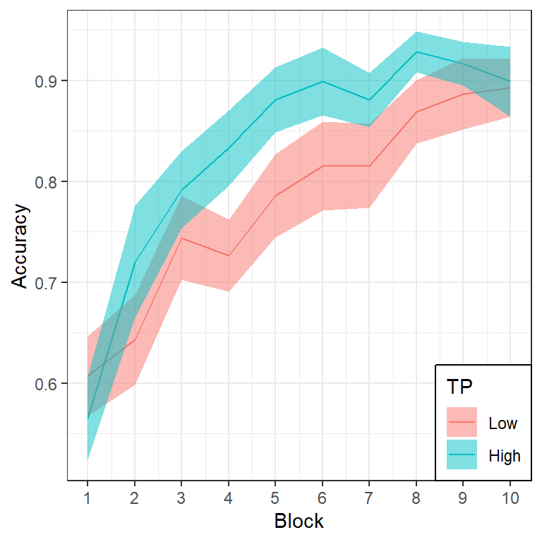

- Novel word learning is faster for high TP than low TP words
- But, t-test on overall mean accuracy is marginal (p=0.096)
- Repeated measures ANOVA shows main effect of Block, marginal effect of TP, and no interaction (F<1)
- Block-by-block t-test significant only in block 4 and marginal in block 5

# Replication crisis

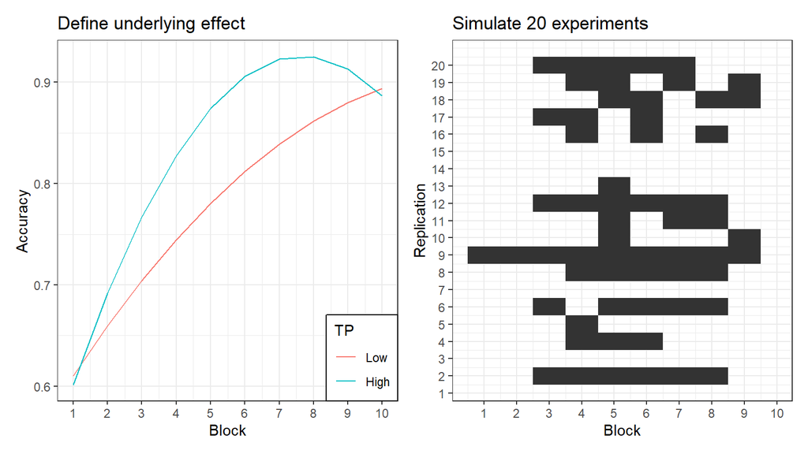

- 5/20 replications had no significant effect in any block
- **Solution**: Use a regression-based approach to analyze the full trajectory

# Nomenclature note

All of these terms refer to the same family of statistical methods, with slight differences in term preference across application domains and in implied data type:

- Multilevel regression (MLR), Multilevel models (MLM)
- Hierarchical linear modeling (HLM)
- Mixed effects models (MEM), Mixed effects regression (MER), Linear mixed models (LMM)
- Growth curve analysis (GCA; implies longitudinal data with non-linear change)

# Linear regression: A brief review

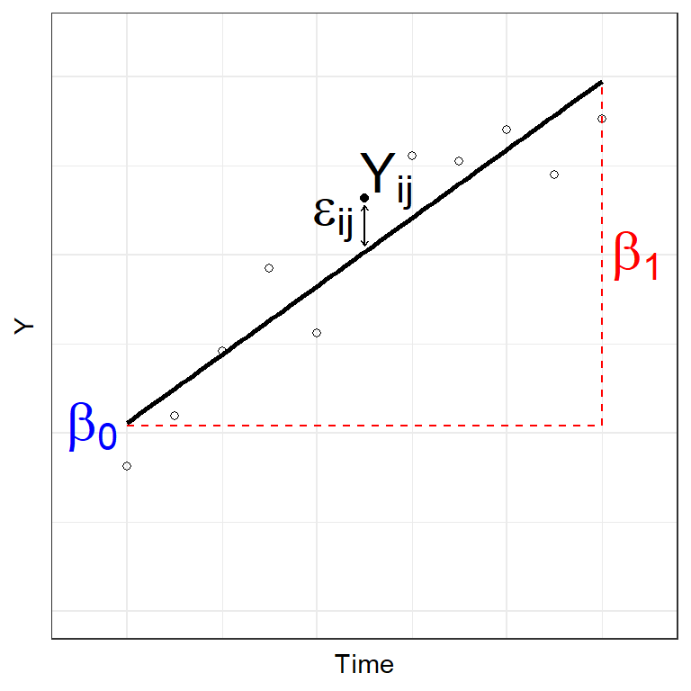

- $Y = \beta_{0} + \beta_{1} \cdot Time$
- $Y_{ij} = \beta_{0i} + \beta_{1i} \cdot Time_{j} + \epsilon_{ij}$
- **Fixed effects**: $\beta_{0}$ (Intercept), $\beta_{1}$ (Slope)
- **Random effects**: $\epsilon_{ij}$ (Residual error)

# Multilevel regression: Fixed effects

Level 1: $Y_{ij} = \beta_{0i} + \beta_{1i} \cdot Time_{j} + \epsilon_{ij}$

Level 2: model of the Level 1 parameter(s)

- $\beta_{0i} = \gamma_{00} + \zeta_{0i}$
  - $\gamma_{00}$ is the population mean
  - $\zeta_{0i}$ is individual deviation from the mean
- $\beta_{0i} = \gamma_{00} + \gamma_{0C} \cdot C + \zeta_{0i}$
  - $\gamma_{0C}$ is the fixed effect of condition $C$ on the *intercept*
- $\beta_{1i} = \gamma_{10} + \gamma_{1C} \cdot C + \zeta_{1i}$
  - $\gamma_{1C}$ is the fixed effect of condition $C$ on the *slope*

# Multilevel regression: Random effects

Level 1: $Y_{ij} = \beta_{0i} + \beta_{1i} \cdot Time_{j} + \epsilon_{ij}$

Level 2:

$\beta_{0i} = \gamma_{00} + \gamma_{0C} \cdot C + \zeta_{0i}$

$\beta_{1i} = \gamma_{10} + \gamma_{1C} \cdot C + \zeta_{1i}$

Residual errors

- $\zeta_{0i}$ unexplained variance in *intercept*
- $\zeta_{1i}$ unexplained variance in *slope*
- Unexplained variance reflects individual differences
- Random effects require a lot of data to estimate

# Fixed vs. Random effects

**Fixed effects**

- Interesting in themselves
- Reproducible fixed properties of the world (nouns vs. verbs, WM load, age, etc.)
- *Unique, unconstrained parameter estimate for each condition*

**Random effects**

- Randomly sampled observational units over which you intend to generalize (particular nouns/verbs, particular individuals, etc.)
- Unexplained variance
- *Drawn from normal distribution with mean 0*

# Maximum Likelihood Estimation

- Find an estimate of parameters that maximizes the likelihood of observing the actual data
- Simple regression: OLS produces MLE parameters by solving an equation
- Multilevel regression: use iterative algorithm to gradually converge to MLE estimates
- Goodness of fit measure: log likelihood (LL)
  - Not inherently meaningful (unlike $R^2$)
  - Change in LL indicates improvement of the fit of the model
  - Changes in $-2LL$ (aka “Likelihood Ratio”") are distributed as $\chi^2$
  - Requires models be nested (parameters added or removed)
  - DF = number of parameters added

# MLR: The core steps

- Load the pacakge: `library(lme4)`
- Fit the model(s): `lmer(formula, data, options)`
- Evaluate the model(s): compare models, examine parameter estimates, plot model fit(s), etc.
- Improve/adjust model(s), rinse, repeat

# A simple MLR example

```r
summary(VisualSearchEx)
```

```
##   Participant        Dx        Set.Size          RT
##  0042   :  4   Aphasic:60   Min.   : 1.0   Min.   :  414
##  0044   :  4   Control:72   1st Qu.: 4.0   1st Qu.: 1132
##  0083   :  4                Median :10.0   Median : 1814
##  0166   :  4                Mean   :12.8   Mean   : 2261
##  0186   :  4                3rd Qu.:18.8   3rd Qu.: 2808
##  0190   :  4                Max.   :30.0   Max.   :12201
##  (Other):108
```

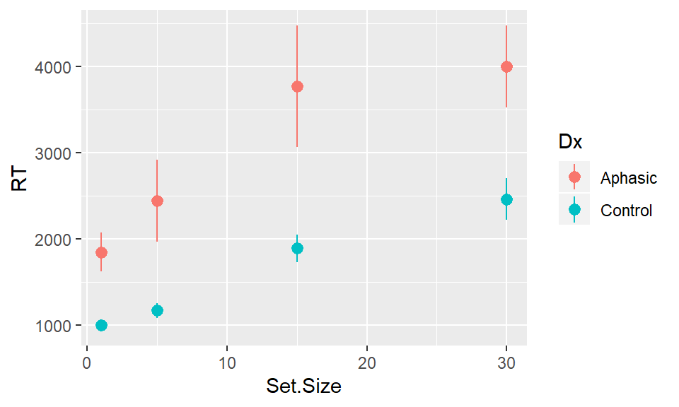

```r
ggplot(VisualSearchEx, aes(Set.Size, RT, color=Dx)) +
  stat_summary(fun.data=mean_se, geom="pointrange")
```

# A simple MLR example: Fit the models

```r
library(lme4)
# a null, intercept-only model
vs.null <- lmer(RT ~ 1 + (Set.Size | Participant), data=VisualSearchEx, REML=FALSE)
# add effect of set size
vs <- lmer(RT ~ Set.Size + (Set.Size | Participant),
           data=VisualSearchEx, REML=F)
```

# A simple MLR example: Fit the models

```r
library(lme4)
# a null, intercept-only model
vs.null <- lmer(RT ~ 1 + (Set.Size | Participant), data=VisualSearchEx, REML=FALSE)
# add effect of set size
vs <- lmer(RT ~ Set.Size + (Set.Size | Participant),
           data=VisualSearchEx, REML=F)
# add effect of diagnosis
vs.0 <- lmer(RT ~ Set.Size + Dx + (Set.Size | Participant),
             data=VisualSearchEx, REML=F)
# add set size by diagnosis interaction
vs.1 <- lmer(RT ~ Set.Size + Dx + Set.Size:Dx + (Set.Size | Participant),
             data=VisualSearchEx, REML=F)
```

# A simple MLR example: Compare the model fits

```r
anova(vs.null, vs, vs.0, vs.1)
```

```
## Data: VisualSearchEx
## Models:
## vs.null: RT ~ 1 + (Set.Size | Participant)
## vs: RT ~ Set.Size + (Set.Size | Participant)
## vs.0: RT ~ Set.Size + Dx + (Set.Size | Participant)
## vs.1: RT ~ Set.Size + Dx + Set.Size:Dx + (Set.Size | Participant)
##         Df  AIC  BIC logLik deviance Chisq Chi Df Pr(>Chisq)
## vs.null  5 2283 2297  -1136     2273
## vs       6 2248 2265  -1118     2236 36.90      1    1.2e-09 ***
## vs.0     7 2241 2261  -1114     2227  8.58      1     0.0034 **
## vs.1     8 2241 2264  -1113     2225  2.01      1     0.1566
## ---
## Signif. codes:  0 '***' 0.001 '**' 0.01 '*' 0.05 '.' 0.1 ' ' 1
```

# A simple MLR example: Interpet results

|  | Df | AIC | BIC | logLik | deviance | Chisq | Chi Df | Pr(>Chisq) |
| --- | --- | --- | --- | --- | --- | --- | --- | --- |
| vs.null | 5 | 2283 | 2297 | -1136 | 2273 | NA | NA | NA |
| vs | 6 | 2248 | 2265 | -1118 | 2236 | 36.903 | 1 | 0.0000 |
| vs.0 | 7 | 2241 | 2261 | -1114 | 2227 | 8.585 | 1 | 0.0034 |
| vs.1 | 8 | 2241 | 2264 | -1113 | 2225 | 2.006 | 1 | 0.1566 |

- Compared to null model, adding set size (`vs`) substantially improves model fit: response times are affected by number of distractors
- Adding effect of Diagnosis on intercept (`vs.0`) significantly improves model fit: stroke survivors respond more slowly than controls do
- Adding interaction of set size and Diagnosis, i.e., effect of Diagnosis on slope (`vs.1`), does not significantly improve model fit: stroke survivors are not more affected by distractors than controls are

# A simple MLR example: Inspect model

```r
summary(vs.1)
```

```
## Linear mixed model fit by maximum likelihood  ['lmerMod']
## Formula: RT ~ Set.Size + Dx + Set.Size:Dx + (Set.Size | Participant)
##    Data: VisualSearchEx
##
##      AIC      BIC   logLik deviance df.resid
##     2241     2264    -1113     2225      124
##
## Scaled residuals:
##    Min     1Q Median     3Q    Max
## -3.759 -0.317 -0.079  0.317  6.229
##
## Random effects:
##  Groups      Name        Variance Std.Dev. Corr
##  Participant (Intercept) 613397   783.2
##              Set.Size       380    19.5    1.00
##  Residual                756827   870.0
## Number of obs: 132, groups:  Participant, 33
##
## Fixed effects:
##                    Estimate Std. Error t value
## (Intercept)          2078.7      264.4    7.86
## Set.Size               73.5       11.2    6.54
## DxControl           -1106.1      357.9   -3.09
## Set.Size:DxControl    -21.7       15.2   -1.43
##
## Correlation of Fixed Effects:
##             (Intr) Set.Sz DxCntr
## Set.Size    -0.090
## DxControl   -0.739  0.066
## St.Sz:DxCnt  0.066 -0.739 -0.090
## convergence code: 0
## boundary (singular) fit: see ?isSingular
```

# A simple MLR example: Parameter p-values

Oh no! `summary()` for models fit by `lme4::lmer` (`lmerMod` objects) does not include p-values.

```
##                    Estimate Std. Error t value
## (Intercept)         2078.75     264.36   7.863
## Set.Size              73.49      11.23   6.545
## DxControl          -1106.05     357.95  -3.090
## Set.Size:DxControl   -21.74      15.20  -1.430
```

- Q: What are those p-values?
- A: One-sample t-tests of whether $Est \neq 0$ with $t = Est/SE$
- But: $df = ???$ because random effects are not free parameters (estimated under constraints)
- So calculating `df` is not trivial, but they can be estimated. Two most common estimations: “Kenward-Roger” and “Satterthwaite”

# A simple MLR example: Parameter p-values

These approximations are implemented in a few different packages (`afex`, `lmerTest`, `pbkrtest`).

For example, with the `lmerTest` package, you can fit the model the same way (it just passes your call to `lmer`) and it will calculate the Satterthwaite approximation and add those `df` and p-values to the model summary

```r
library(lmerTest)
vs.1 <- lmer(RT ~ Set.Size + Dx + Set.Size:Dx + (Set.Size | Participant),
             data=VisualSearchEx, REML=F)
summary(vs.1)
```

```
## Linear mixed model fit by maximum likelihood . t-tests use Satterthwaite's
##   method [lmerModLmerTest]
## Formula: RT ~ Set.Size + Dx + Set.Size:Dx + (Set.Size | Participant)
##    Data: VisualSearchEx
##
##      AIC      BIC   logLik deviance df.resid
##     2241     2264    -1113     2225      124
##
## Scaled residuals:
##    Min     1Q Median     3Q    Max
## -3.759 -0.317 -0.079  0.317  6.229
##
## Random effects:
##  Groups      Name        Variance Std.Dev. Corr
##  Participant (Intercept) 613397   783.2
##              Set.Size       380    19.5    1.00
##  Residual                756827   870.0
## Number of obs: 132, groups:  Participant, 33
##
## Fixed effects:
##                    Estimate Std. Error      df t value Pr(>|t|)
## (Intercept)          2078.7      264.4    35.7    7.86  2.6e-09 ***
## Set.Size               73.5       11.2    54.9    6.54  2.1e-08 ***
## DxControl           -1106.1      357.9    35.7   -3.09   0.0039 **
## Set.Size:DxControl    -21.7       15.2    54.9   -1.43   0.1585
## ---
## Signif. codes:  0 '***' 0.001 '**' 0.01 '*' 0.05 '.' 0.1 ' ' 1
##
## Correlation of Fixed Effects:
##             (Intr) Set.Sz DxCntr
## Set.Size    -0.090
## DxControl   -0.739  0.066
## St.Sz:DxCnt  0.066 -0.739 -0.090
## convergence code: 0
## boundary (singular) fit: see ?isSingular
```

# A simple MLR example: Plot model fit

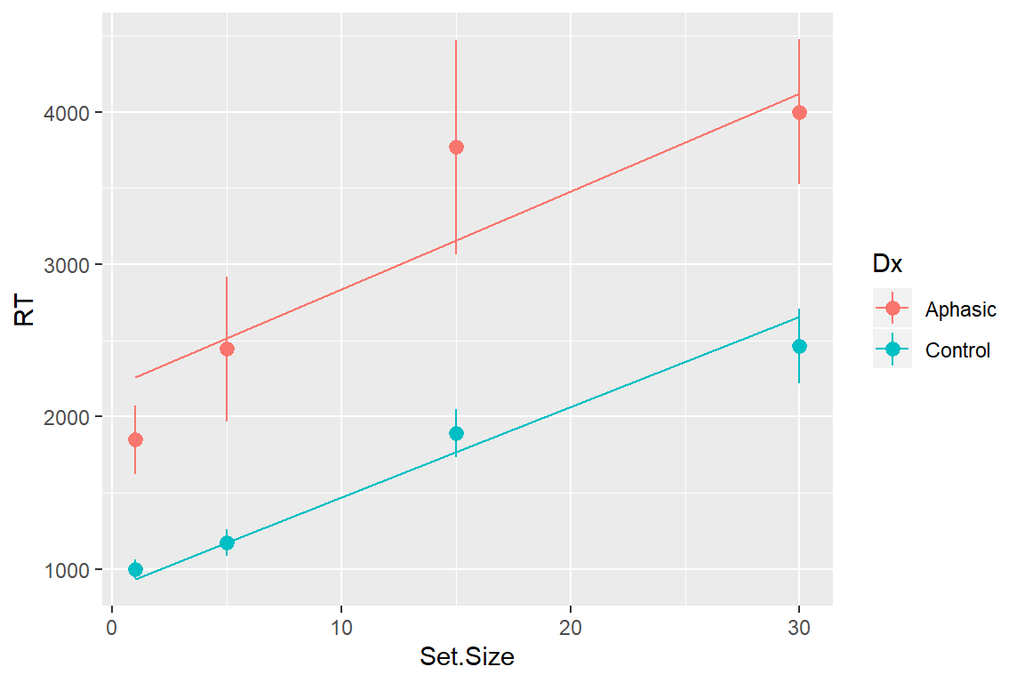

```r
ggplot(VisualSearchEx, aes(Set.Size, RT, color=Dx)) +
  stat_summary(fun.data=mean_se, geom="pointrange") +
  stat_summary(aes(y=fitted(vs.0)), fun.y=mean, geom="line")
```

# A simple MLR example: Compare model fits

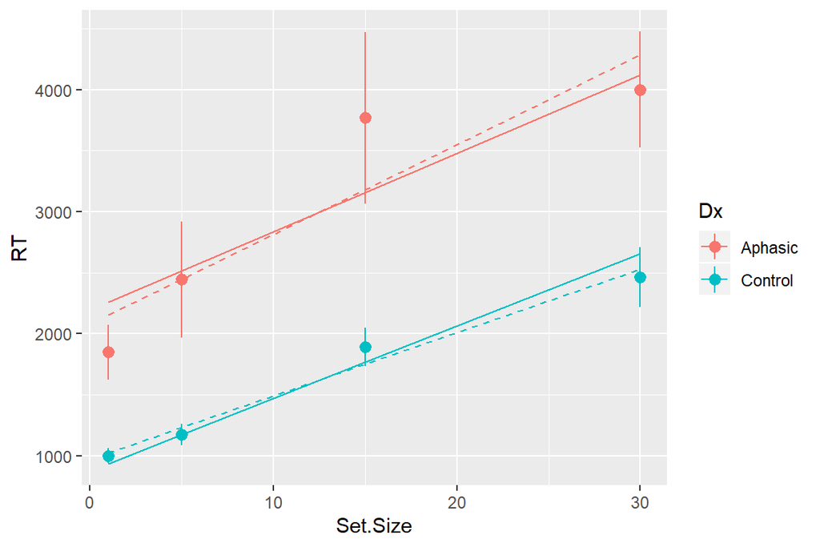

```r
ggplot(VisualSearchEx, aes(Set.Size, RT, color=Dx)) +
  stat_summary(fun.data=mean_se, geom="pointrange") +
  stat_summary(aes(y=fitted(vs.0)), fun.y=mean, geom="line") +
  stat_summary(aes(y=fitted(vs.1)), fun.y=mean, geom="line", linetype="dashed")
```

# Another way to plot model fit

The `effects` package provides a convenient way to pull estimated values from a model (along with SE and confidence intervals). Very useful for plotting effects from complicated models, or when there are missing data, etc.

```r
library(effects)
ef <- as.data.frame(effect("Set.Size:Dx", vs.0))
head(ef)
```

```
##   Set.Size      Dx  fit    se  lower upper
## 1      1.0 Aphasic 2162 262.3 1643.0  2681
## 2      8.2 Aphasic 2606 266.8 2077.8  3133
## 3     16.0 Aphasic 3086 284.1 2524.3  3649
## 4     23.0 Aphasic 3518 309.0 2906.5  4129
## 5     30.0 Aphasic 3949 340.7 3275.3  4623
## 6      1.0 Control 1016 239.4  542.7  1490
```

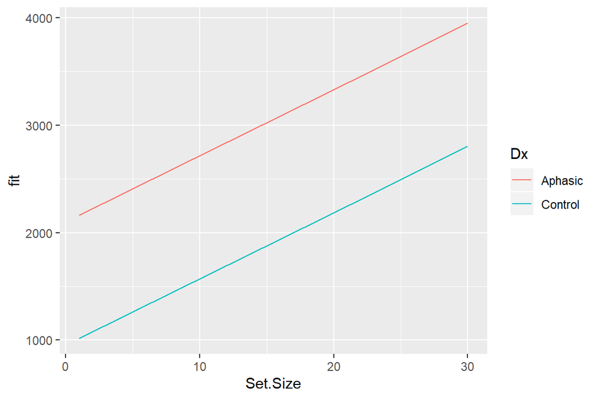

```r
ggplot(ef, aes(Set.Size, fit, color=Dx)) +
  geom_line()
```

# 10-minute break

# Why logistic regression? (A brief review)

Aggregated binary outcomes (e.g., accuracy, fixation proportion) can look approximately continuous, but they

- Are bounded: can only have values between 0.0 and 1.0
- Have very specific, non-uniform variance pattern

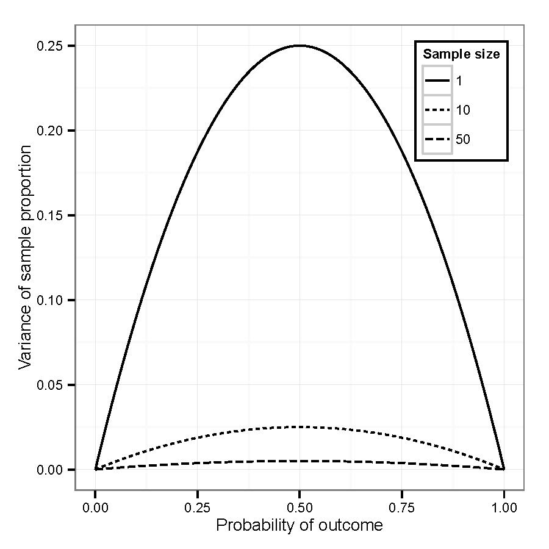

# Why logistic regression? (A brief review)

These properties can produce incorrect results in linear regression.

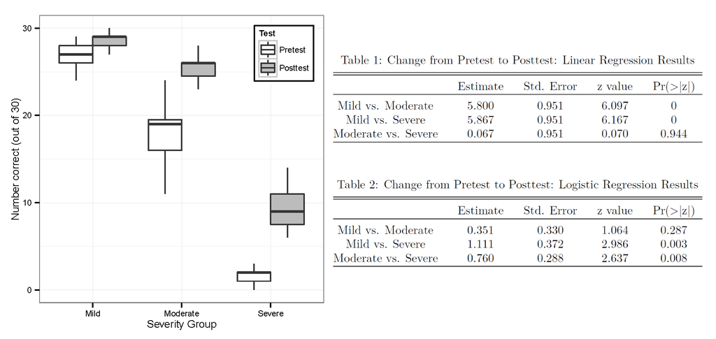

# Logistic regression (A brief review)

- Model the binomial process that produced binary data
- Not enough to know that accuracy was 90%, need to know whether that was 9 out of 10 trials or 90 out of 100 trials
- Can be a binary vector of single-trial 0’s (failures, No’s) or 1’s (successes, Yes’s)
- More compact version: count of the number of successes and the number of failures

Outcome is log-odds (also called “logit”): $logit(Yes, No) = \log \left(\frac{Yes}{No}\right)$

Compare to proportions: $p(Yes, No) = \frac{Yes}{Yes+No}$

Note: logit is undefined (`Inf`) when $p=0$ or $p=1$, this makes it hard to fit logistic models to data with such extreme values (e.g., fixations on objects that are very rarely fixated).

# Example Data

Novel word learning (`nwl`) in aphasia (based on Peñaloza et al., 2016). Participants were 27 older adults (13 with aphasia, 14 control) who completed a short training session to learn 6 new words: made-up labels for ancient farming equipment. There were 7 blocks of training trials, followed by an immediate recall test block, and there was a follow-up test block 1 week later. Each block consisted of 30 2AFC trials, feedback was provided during the training blocks but not during the test blocks.

```r
load("../data/nwl.RData")
summary(nwl)
```

```
##      group      lesion_location     block    PropCorrect      NumCorrect
##  control:126   anterior : 45    Min.   :1   Min.   :0.200   Min.   : 6.0
##  patient:117   posterior: 63    1st Qu.:3   1st Qu.:0.533   1st Qu.:16.0
##                NA's     :135    Median :5   Median :0.700   Median :21.0
##                                 Mean   :5   Mean   :0.682   Mean   :20.5
##                                 3rd Qu.:7   3rd Qu.:0.833   3rd Qu.:25.0
##                                 Max.   :9   Max.   :1.000   Max.   :30.0
##
##     NumError             ID         Phase
##  Min.   : 0.00   control1 :  9   Length:243
##  1st Qu.: 5.00   control10:  9   Class :character
##  Median : 9.00   control11:  9   Mode  :character
##  Mean   : 9.54   control12:  9
##  3rd Qu.:14.00   control13:  9
##  Max.   :24.00   control14:  9
##                  (Other)  :189
```

# Example Data

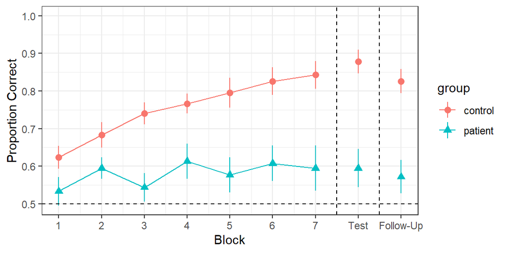

```r
ggplot(nwl, aes(block, PropCorrect, color=group, shape=group)) +
  stat_summary(fun.data=mean_se, geom="pointrange") +
  stat_summary(data=filter(nwl, block <= 7), fun.y=mean, geom="line") +
  geom_hline(yintercept=0.5, linetype="dashed") +
  geom_vline(xintercept=c(7.5, 8.5), linetype="dashed") +
  scale_x_continuous(breaks=1:9, labels=c(1:7, "Test", "Follow-Up")) +
  expand_limits(y=1.0) +
  theme_bw() + labs(x="Block", y="Proportion Correct")
```

Research questions (just focus on test data for now):

- Were patients with aphasia less successful than controls were at learning these new words? (Lower test performance)
- Did recall decrease from immediate test to 1-week follow-up?
- Was retention (recall decrease) different for the two groups?

Note: One might be tempted to test this with a 2x2 ANOVA. In what ways is that right? In what ways is that wrong?

# 2x2 ANOVA

- What it gets right
  - Group as a between-participant variable, Phase as a within-participant variable (MLR is a more flexible version of repeated measures ANOVA)
  - Phase-by-group interaction
- What is wrong
  - Accuracy is not a continuous linear variable, it is an aggregated binary variable

# Logistic MLR: Fit the model

Logistic model code is almost the same as linear model code. Three differences:

1. `glmer()` instead of `lmer()`
2. outcome is 1/0 or aggregated number of 1s, 0s
3. add `family=binomial`

```r
m.recall <- glmer(cbind(NumCorrect, NumError) ~ Phase * group +
                    (Phase | ID),
                   data=filter(nwl, block > 7), family="binomial")
```

```
## boundary (singular) fit: see ?isSingular
```

Note: Logistic MLR models are slower to fit and are prone to convergence problems.

- May need to simplify random effect structure
- Convergence warnings: A warning is not an error – will need to check parameter estimates and SE
- Singular fit message: A message is not an error – will need to assess reason for message and consider changes to the model

# Logistic MLR: Model summary

```r
summary(m.recall)
```

```
## Generalized linear mixed model fit by maximum likelihood (Laplace
##   Approximation) [glmerMod]
##  Family: binomial  ( logit )
## Formula: cbind(NumCorrect, NumError) ~ Phase * group + (Phase | ID)
##    Data: filter(nwl, block > 7)
##
##      AIC      BIC   logLik deviance df.resid
##    283.2    297.1   -134.6    269.2       47
##
## Scaled residuals:
##     Min      1Q  Median      3Q     Max
## -1.2676 -0.4586  0.0526  0.4553  1.2636
##
## Random effects:
##  Groups Name           Variance Std.Dev. Corr
##  ID     (Intercept)    0.4635   0.681
##         PhaseImmediate 0.0505   0.225    1.00
## Number of obs: 54, groups:  ID, 27
##
## Fixed effects:
##                             Estimate Std. Error z value Pr(>|z|)
## (Intercept)                    1.719      0.231    7.45  9.1e-14 ***
## PhaseImmediate                 0.582      0.232    2.51    0.012 *
## grouppatient                  -1.388      0.316   -4.40  1.1e-05 ***
## PhaseImmediate:grouppatient   -0.441      0.278   -1.59    0.113
## ---
## Signif. codes:  0 '***' 0.001 '**' 0.01 '*' 0.05 '.' 0.1 ' ' 1
##
## Correlation of Fixed Effects:
##             (Intr) PhsImm grpptn
## PhaseImmedt -0.141
## grouppatint -0.725  0.094
## PhsImmdt:gr  0.108 -0.800 -0.066
## convergence code: 0
## boundary (singular) fit: see ?isSingular
```

# Contrast coding

In `R`, the default for factors is “treatment” coding: the reference level is the baseline. This means that the parameter estimates are *simple* effects.

- `PhaseImmediate`: effect of test phase *for control group* (reference level of `group`)
- `grouppatient`: effect of group *at follow-up* (reference level for `Phase`)

# Contrast coding: estimating main effects

To estimate main effects, need to use “sum” coding:

```r
m.recall_sum <- glmer(cbind(NumCorrect, NumError) ~ Phase * group +
                        (Phase | ID),
                      contrasts = list(Phase = "contr.sum",
                                       group = "contr.sum"),
                   data=filter(nwl, block > 7), family="binomial")
```

```
## boundary (singular) fit: see ?isSingular
```

```r
coef(summary(m.recall_sum))
```

```
##               Estimate Std. Error z value  Pr(>|z|)
## (Intercept)     1.2060    0.16911   7.132 9.917e-13
## Phase1         -0.1808    0.07326  -2.468 1.359e-02
## group1          0.8045    0.16819   4.783 1.725e-06
## Phase1:group1  -0.1102    0.06946  -1.587 1.125e-01
```

# Logistic MLR: Plot model fit

The `fitted` function conveniently returns proportions from a logistic model, so plotting the model fit is easy:

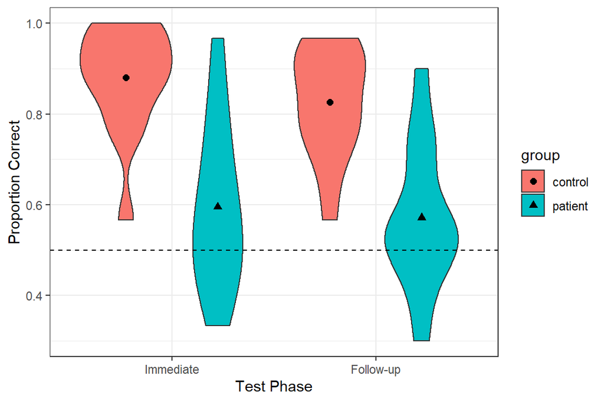

```r
ggplot(filter(nwl, block > 7), aes(fct_rev(Phase), PropCorrect, fill=group)) +
  geom_violin() +
  stat_summary(aes(y=fitted(m.recall_sum), shape=group),
               fun.y=mean, geom = "point", size=2,
               position=position_dodge(width=.9)) +
  geom_hline(yintercept = 0.5, linetype="dashed") +
  theme_bw() + labs(y="Proportion Correct", x="Test Phase")
```

# Simplify random effects

There is some disagreement about the *right* way to structure random effects. The core issues are:

1. For within-subject variables, omitting the random effect tends to inflate false positive rates of the corresponding fixed effect (Barr et al., 2013). So if you want to make inferences about a (within-subject) fixed effect, you should include the corresponding random effect (*Keep it maximal*).
2. Random effects require a lot of data to estimate, so it is easy to over-parameterize a model with random effects (you’ll get convergence warnings or messages). Poor convergence can mean that there may be other fixed effect estimates that are (nearly) equally good at describing your data, which is a problem since you want to make inferences based on the fixed effect estimates.

# Simplify random effects

There is some disagreement about the *right* way to structure random effects. The core issues are:

1. For within-subject variables, omitting the random effect tends to inflate false positive rates of the corresponding fixed effect (Barr et al., 2013). So if you want to make inferences about a (within-subject) fixed effect, you should include the corresponding random effect (*Keep it maximal*).
2. Random effects require a lot of data to estimate, so it is easy to over-parameterize a model with random effects (you’ll get convergence warnings or messages). Poor convergence can mean that there may be other fixed effect estimates that are (nearly) equally good at describing your data, which is a problem since you want to make inferences based on the fixed effect estimates.

**Solutions**

- Start with a maximal random effect structure
- In case of convergence problems, look at the random effect varaince-covariance matrix: are there terms with very low variance or unrealistic covariance (-1 or 1)? Consider removing these.
- Compare fixed effect estimates under different random effect structures: ideally, the fixed effect estimates and SE should be (approximately) the same. If they are substantially different, then your modeling approach is not robust and you should reconsider and/or be *very* cautious about interpreting the results.

# Key points

- What are nested data?
- Core conceptual basis of multilevel regression
- Fitting MLR models with `lme4`
  - Interpreting, comparing, and plotting MLR models
- Fitting logistic MLR models